# Análise Exploratória de Dados

Exploratory Data Analysis (EDA)

# Bibliotecas

```r
library(tidyverse)
```

# Introdução

Neste arquivo serão apresentados conceitos de EDA, bem como bibliotecas uteis do R para este fim. Posteriormente aprofundaremos sobre quais pontos devem ser considerados em uma análise descritiva, considerando o ferramental disponibilizado pela estatística.

# O que é EDA?

EDA, do inglês Exploratory Data Analysis, e em português Análise Exploratória de Dados, trata o processo de explorar os dados. O que, tipicamente, inclui desde examinar a estrutura do dataset — que iniciamos no módulo anterior, até o entendimento mais profundo sobre o comportamento das variáveis — nosso foco neste módulo. A EDA nos permite:

- Observar padrões não necessariamente conhecidos a priori;
- Identificar se há alguma inconsistência no conjunto de dados analisado;
- Determinar se as perguntas relacionadas aos dados podem ser respondidas pelas informações disponíveis; e
- Desenvolver um esboço de resposta para as hipóteses levantadas, por vezes respondê-las.

Aqui é podemos tanto ir em uma linha de exploração descritiva, por meio de volumetrias, estatísticas e visualizações, quanto utilizar uma abordagem mais diagnóstica, investigando comportamentos mais complexos, como padrões de associação, por exemplo. Em linhas gerais, é nesta etapa que *aprendemos* e damos *sentido* aos dados!

# Base de Dados: Super Bowl Americano

Vamos trabalhar com uma base de comerciais do Super Bowl Americano, considerando os anúncios das 10 marcas que mais veicularam neste evento nos últimos anos, tendo, para cada comercial, uma classificação binária relacionada a critérios pré-especificados. Para mais informações sobre o levantamento e/ou os dados acesse:

- https://projects.fivethirtyeight.com/super-bowl-ads/
- https://github.com/rfordatascience/tidytuesday/blob/master/data/2021/2021-03-02/readme.md

```r
youtube <- readr::read_csv(
  'https://raw.githubusercontent.com/rfordatascience/tidytuesday/master/data/2021/2021-03-02/youtube.csv')
#caso não tenha acesso a internet, pelo código abaixo, a base foi salva e, na sequencia, pode ser novamente lida a partir do arquivo .csv salvo na pasta dados
  #readr::write_csv(youtube, "..\\dados\\youtube.csv")
  #youtube <- readr::read_csv("..\\dados\\youtube.csv")
```

```r
youtube %>% glimpse()
```

```
## Rows: 247
## Columns: 25
## $ year                      <dbl> 2018, 2020, 2006, 2018, 2003, 2020, 2020, 20…
## $ brand                     <chr> "Toyota", "Bud Light", "Bud Light", "Hynudai…
## $ superbowl_ads_dot_com_url <chr> "https://superbowl-ads.com/good-odds-toyota/…
## $ youtube_url               <chr> "https://www.youtube.com/watch?v=zeBZvwYQ-hA…
## $ funny                     <lgl> FALSE, TRUE, TRUE, FALSE, TRUE, TRUE, TRUE, …
## $ show_product_quickly      <lgl> FALSE, TRUE, FALSE, TRUE, TRUE, TRUE, FALSE,…
## $ patriotic                 <lgl> FALSE, FALSE, FALSE, FALSE, FALSE, FALSE, FA…
## $ celebrity                 <lgl> FALSE, TRUE, FALSE, FALSE, FALSE, TRUE, TRUE…
## $ danger                    <lgl> FALSE, TRUE, TRUE, FALSE, TRUE, TRUE, FALSE,…
## $ animals                   <lgl> FALSE, FALSE, TRUE, FALSE, TRUE, TRUE, TRUE,…
## $ use_sex                   <lgl> FALSE, FALSE, FALSE, FALSE, TRUE, FALSE, FAL…
## $ id                        <chr> "zeBZvwYQ-hA", "nbbp0VW7z8w", "yk0MQD5YgV8",…
## $ kind                      <chr> "youtube#video", "youtube#video", "youtube#v…
## $ etag                      <chr> "rn-ggKNly38Cl0C3CNjNnUH9xUw", "1roDoK-SYqSp…
## $ view_count                <dbl> 173929, 47752, 142310, 198, 13741, 23636, 30…
## $ like_count                <dbl> 1233, 485, 129, 2, 20, 115, 1470, 78, 342, 7…
## $ dislike_count             <dbl> 38, 14, 15, 0, 3, 11, 384, 6, 7, 0, 14, 0, 2…
## $ favorite_count            <dbl> 0, 0, 0, 0, 0, 0, 0, 0, 0, 0, 0, 0, 0, 0, 0,…
## $ comment_count             <dbl> NA, 14, 9, 0, 2, 13, 227, 6, 30, 0, 8, 1, 13…
## $ published_at              <dttm> 2018-02-03 11:29:14, 2020-01-31 21:04:13, 2…
## $ title                     <chr> "Toyota Super Bowl Commercial 2018 Good Odds…
## $ description               <chr> "Toyota Super Bowl Commercial 2018 Good Odds…
## $ thumbnail                 <chr> "https://i.ytimg.com/vi/zeBZvwYQ-hA/sddefaul…
## $ channel_title             <chr> "Funny Commercials", "VCU Brandcenter", "Joh…
## $ category_id               <dbl> 1, 27, 17, 22, 24, 1, 24, 2, 24, 24, 24, 24,…
```

# Bibliotecas para EDA

Vamos iniciar fazendo uso de pacotes que nos ajudam a entender as principais características dos dados:

## janitor

O pacote `janitor`, algo como `faxineiro` em inglês, disponibiliza algumas funções para limpar e avaliar bases de dados, com funções como:

- `janitor::remove_empty_cols()` para a remoção de colunas vazias;
- `janitor::get_dupes()` para a identificação de linhas duplicadas; e
- `janitor::round_half_up()` para arredondar resultados numéricos.

Ah, tem uma função MUITO legal, `janitor::clean_names()` que limpa o nome das colunas — facilmente uma das minha top5 funções preferidas. Para a base do Super Bowl ela não se faz necessária, visto que os nomes da coluna já estão em um ótimo formato. Mas mais para frente passaremos por um exemplo em que esta função será super útil. Apenas para ilustrar o seu uso, segue uma aplicação desta função considerando uma das suas possíveis variações (via alteração do parâmetro `case`), para a modição do estilo das colunas :

```r
#janitor::
youtube %>% janitor::clean_names(case = "upper_camel") %>%  glimpse()
```

```
## Rows: 247
## Columns: 25
## $ Year                  <dbl> 2018, 2020, 2006, 2018, 2003, 2020, 2020, 2020, …
## $ Brand                 <chr> "Toyota", "Bud Light", "Bud Light", "Hynudai", "…
## $ SuperbowlAdsDotComUrl <chr> "https://superbowl-ads.com/good-odds-toyota/", "…
## $ YoutubeUrl            <chr> "https://www.youtube.com/watch?v=zeBZvwYQ-hA", "…
## $ Funny                 <lgl> FALSE, TRUE, TRUE, FALSE, TRUE, TRUE, TRUE, FALS…
## $ ShowProductQuickly    <lgl> FALSE, TRUE, FALSE, TRUE, TRUE, TRUE, FALSE, FAL…
## $ Patriotic             <lgl> FALSE, FALSE, FALSE, FALSE, FALSE, FALSE, FALSE,…
## $ Celebrity             <lgl> FALSE, TRUE, FALSE, FALSE, FALSE, TRUE, TRUE, TR…
## $ Danger                <lgl> FALSE, TRUE, TRUE, FALSE, TRUE, TRUE, FALSE, FAL…
## $ Animals               <lgl> FALSE, FALSE, TRUE, FALSE, TRUE, TRUE, TRUE, FAL…
## $ UseSex                <lgl> FALSE, FALSE, FALSE, FALSE, TRUE, FALSE, FALSE, …
## $ Id                    <chr> "zeBZvwYQ-hA", "nbbp0VW7z8w", "yk0MQD5YgV8", "lN…
## $ Kind                  <chr> "youtube#video", "youtube#video", "youtube#video…
## $ Etag                  <chr> "rn-ggKNly38Cl0C3CNjNnUH9xUw", "1roDoK-SYqSpqYwK…
## $ ViewCount             <dbl> 173929, 47752, 142310, 198, 13741, 23636, 304254…
## $ LikeCount             <dbl> 1233, 485, 129, 2, 20, 115, 1470, 78, 342, 7, 46…
## $ DislikeCount          <dbl> 38, 14, 15, 0, 3, 11, 384, 6, 7, 0, 14, 0, 24, 1…
## $ FavoriteCount         <dbl> 0, 0, 0, 0, 0, 0, 0, 0, 0, 0, 0, 0, 0, 0, 0, 0, …
## $ CommentCount          <dbl> NA, 14, 9, 0, 2, 13, 227, 6, 30, 0, 8, 1, 13, 50…
## $ PublishedAt           <dttm> 2018-02-03 11:29:14, 2020-01-31 21:04:13, 2006-…
## $ Title                 <chr> "Toyota Super Bowl Commercial 2018 Good Odds", "…
## $ Description           <chr> "Toyota Super Bowl Commercial 2018 Good Odds. Yo…
## $ Thumbnail             <chr> "https://i.ytimg.com/vi/zeBZvwYQ-hA/sddefault.jp…
## $ ChannelTitle          <chr> "Funny Commercials", "VCU Brandcenter", "John Ke…
## $ CategoryId            <dbl> 1, 27, 17, 22, 24, 1, 24, 2, 24, 24, 24, 24, 24,…
```

Este pacote também nos possibilita criar tabelas de frequência rapidamente:

```r
youtube %>% janitor::tabyl(brand)
```

```
##      brand  n    percent
##  Bud Light 63 0.25506073
##  Budweiser 43 0.17408907
##  Coca-Cola 21 0.08502024
##    Doritos 25 0.10121457
##    E-Trade 13 0.05263158
##    Hynudai 22 0.08906883
##        Kia 13 0.05263158
##        NFL 11 0.04453441
##      Pepsi 25 0.10121457
##     Toyota 11 0.04453441
```

E mais, deixar a tabela em um formato bonitinho :)

```r
youtube %>%
  janitor::tabyl(brand) %>%
  janitor::adorn_totals() %>%
  janitor::adorn_pct_formatting()
```

```
##      brand   n percent
##  Bud Light  63   25.5%
##  Budweiser  43   17.4%
##  Coca-Cola  21    8.5%
##    Doritos  25   10.1%
##    E-Trade  13    5.3%
##    Hynudai  22    8.9%
##        Kia  13    5.3%
##        NFL  11    4.5%
##      Pepsi  25   10.1%
##     Toyota  11    4.5%
##      Total 247  100.0%
```

Essa mesma função funciona também para visualizar duas variáveis de modo combinado — este tipo de tabela é usualmente conhecido como `Tabela de Contingência`:

```r
youtube %>%
  janitor::tabyl(brand, celebrity) %>%
  janitor::adorn_totals(c("row", "col"))
```

```
##      brand FALSE TRUE Total
##  Bud Light    46   17    63
##  Budweiser    38    5    43
##  Coca-Cola    15    6    21
##    Doritos    21    4    25
##    E-Trade    13    0    13
##    Hynudai    16    6    22
##        Kia     6    7    13
##        NFL     3    8    11
##      Pepsi     9   16    25
##     Toyota     9    2    11
##      Total   176   71   247
```

```r
youtube %>%
  janitor::tabyl(brand, celebrity) %>%
  janitor::adorn_totals(c("row", "col")) %>%
  janitor::adorn_percentages("row") %>%
  janitor::adorn_pct_formatting()
```

```
##      brand  FALSE  TRUE  Total
##  Bud Light  73.0% 27.0% 100.0%
##  Budweiser  88.4% 11.6% 100.0%
##  Coca-Cola  71.4% 28.6% 100.0%
##    Doritos  84.0% 16.0% 100.0%
##    E-Trade 100.0%  0.0% 100.0%
##    Hynudai  72.7% 27.3% 100.0%
##        Kia  46.2% 53.8% 100.0%
##        NFL  27.3% 72.7% 100.0%
##      Pepsi  36.0% 64.0% 100.0%
##     Toyota  81.8% 18.2% 100.0%
##      Total  71.3% 28.7% 100.0%
```

```r
#janitor::
```

## inspectdf

O pacote `inspectdf` faz exatamente o que o nome sugere, nos auxilia a inspecionar dados por meio de uma série de recursos para apresentação de resumos dos dado, como: contabilização de volumetrias e dados faltantes. Tendo sempre direcionamento a classe das variáveis – lembrando que já discutimos sobre o quão importante este conceito é, tanto a partir da óptica estatística, quanto no contexto computacional, considerando a interpretação da linguagem R. Vamos avaliar alguns dos resultados:

```r
#inspectdf::
youtube %>% inspectdf::inspect_types()
```

```
## # A tibble: 4 × 4
##   type             cnt  pcnt col_name
##   <chr>          <int> <dbl> <named list>
## 1 character         10    40 <chr [10]>
## 2 logical            7    28 <chr [7]>
## 3 numeric            7    28 <chr [7]>
## 4 POSIXct POSIXt     1     4 <chr [1]>
```

Apesar de não priorizarmos dados do tipo lista neste curso, vou deixar aqui um exemplo de como poderiamos consultar colunas que possuam esta estrutura:

```r
youtube %>% inspectdf::inspect_types() %>% pull(col_name)
```

```
## $character
##                           2                           3
##                     "brand" "superbowl_ads_dot_com_url"
##                           4                          12
##               "youtube_url"                        "id"
##                          13                          14
##                      "kind"                      "etag"
##                          21                          22
##                     "title"               "description"
##                          23                          24
##                 "thumbnail"             "channel_title"
##
## $logical
##                      5                      6                      7
##                "funny" "show_product_quickly"            "patriotic"
##                      8                      9                     10
##            "celebrity"               "danger"              "animals"
##                     11
##              "use_sex"
##
## $numeric
##                1               15               16               17
##           "year"     "view_count"     "like_count"  "dislike_count"
##               18               19               25
## "favorite_count"  "comment_count"    "category_id"
##
## $`POSIXct POSIXt`
##             20
## "published_at"
```

Podemos também ter visibilidade dos níveis mais frequente de cada uma das variáveis categóricas:

```r
youtube %>% inspectdf::inspect_imb()
```

```
## # A tibble: 17 × 4
##    col_name                  value                                    pcnt   cnt
##    <chr>                     <chr>                                   <dbl> <int>
##  1 kind                      youtube#video                          93.5     231
##  2 patriotic                 FALSE                                  83.4     206
##  3 use_sex                   FALSE                                  73.3     181
##  4 celebrity                 FALSE                                  71.3     176
##  5 danger                    FALSE                                  69.6     172
##  6 funny                     TRUE                                   69.2     171
##  7 show_product_quickly      TRUE                                   68.4     169
##  8 animals                   FALSE                                  62.8     155
##  9 brand                     Bud Light                              25.5      63
## 10 channel_title             NFL                                     2.02      5
## 11 superbowl_ads_dot_com_url https://superbowl-ads.com/2005-bud-li…  1.62      4
## 12 youtube_url               https://www.youtube.com/watch?v=Q5Hu_…  1.62      4
## 13 id                        Q5Hu_FBUIsk                             1.62      4
## 14 etag                      R_HCqypuDt6rx8JX6DU3K7wTXwY             1.62      4
## 15 title                     Bud Lighta Cedric a Island Fantasy 20…  1.62      4
## 16 description               Bud Lighta Cedric a Island Fantasy 20…  1.62      4
## 17 thumbnail                 https://i.ytimg.com/vi/-BVMOKtawUk/sd…  0.405     1
```

Ou ainda a versão gráfica da tabela acima:

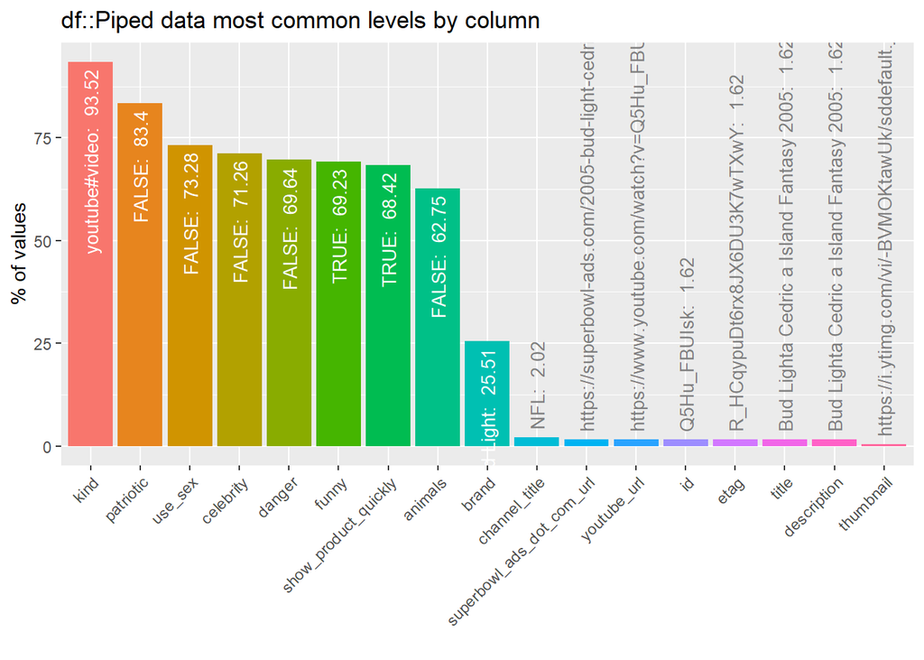

```r
youtube %>% inspectdf::inspect_imb() %>% inspectdf::show_plot()
```

Bem como recursos sobre os dados faltantes por coluna:

```r
youtube %>% inspectdf::inspect_na()
```

```
## # A tibble: 25 × 3
##    col_name         cnt  pcnt
##    <chr>          <int> <dbl>
##  1 thumbnail        129 52.2
##  2 description       50 20.2
##  3 comment_count     25 10.1
##  4 like_count        22  8.91
##  5 dislike_count     22  8.91
##  6 kind              16  6.48
##  7 etag              16  6.48
##  8 view_count        16  6.48
##  9 favorite_count    16  6.48
## 10 published_at      16  6.48
## # … with 15 more rows
```

Ou ainda medidas de resumo relacionadas às variáveis numéricas:

```r
youtube %>% inspectdf::inspect_num()
```

```
## # A tibble: 7 × 10
##   col_name         min    q1 median   mean     q3    max     sd pcnt_na hist
##   <chr>          <dbl> <dbl>  <dbl>  <dbl>  <dbl>  <dbl>  <dbl>   <dbl> <named >
## 1 year            2000  2005   2010 2.01e3 2.02e3 2.02e3 5.86e0    0    <tibble>
## 2 view_count        10  6431  41379 1.41e6 1.70e5 1.76e8 1.20e7    6.48 <tibble>
## 3 like_count         0    19    130 4.15e3 5.27e2 2.75e5 2.39e4    8.91 <tibble>
## 4 dislike_count      0     1      7 8.34e2 2.4 e1 9.30e4 6.95e3    8.91 <tibble>
## 5 favorite_count     0     0      0 0      0      0      0         6.48 <tibble>
## 6 comment_count      0     1     10 1.89e2 5.08e1 9.19e3 9.86e2   10.1  <tibble>
## 7 category_id        1    17     23 1.93e1 2.4 e1 2.9 e1 8.00e0    6.48 <tibble>
```

## skimr

Em português skim significa algo como “tirar a nata”, no caso, tirar a nata dos dados. E é isto que o pacote `skimr` faz, visto que nos permitir uma visão macro de toda a base, com uma serie de estatísticas organizadas de acordo com a classe das colunas – inclusive com um gráfico de frequência! Muito legal né? :p

```r
#skimr::
youtube %>%  skimr::skim()
```

Data summary

| Name | Piped data |
| --- | --- |
| Number of rows | 247 |
| Number of columns | 25 |
| _______________________ |  |
| Column type frequency: |  |
| character | 10 |
| logical | 7 |
| numeric | 7 |
| POSIXct | 1 |
| ________________________ |  |
| Group variables | None |

**Variable type: character**

| skim_variable | n_missing | complete_rate | min | max | empty | n_unique | whitespace |
| --- | --- | --- | --- | --- | --- | --- | --- |
| brand | 0 | 1.00 | 3 | 9 | 0 | 10 | 0 |
| superbowl_ads_dot_com_url | 0 | 1.00 | 34 | 120 | 0 | 244 | 0 |
| youtube_url | 11 | 0.96 | 43 | 43 | 0 | 233 | 0 |
| id | 11 | 0.96 | 11 | 11 | 0 | 233 | 0 |
| kind | 16 | 0.94 | 13 | 13 | 0 | 1 | 0 |
| etag | 16 | 0.94 | 27 | 27 | 0 | 228 | 0 |
| title | 16 | 0.94 | 6 | 99 | 0 | 228 | 0 |
| description | 50 | 0.80 | 3 | 3527 | 0 | 194 | 0 |
| thumbnail | 129 | 0.48 | 48 | 48 | 0 | 118 | 0 |
| channel_title | 16 | 0.94 | 3 | 37 | 0 | 185 | 0 |

**Variable type: logical**

| skim_variable | n_missing | complete_rate | mean | count |
| --- | --- | --- | --- | --- |
| funny | 0 | 1 | 0.69 | TRU: 171, FAL: 76 |
| show_product_quickly | 0 | 1 | 0.68 | TRU: 169, FAL: 78 |
| patriotic | 0 | 1 | 0.17 | FAL: 206, TRU: 41 |
| celebrity | 0 | 1 | 0.29 | FAL: 176, TRU: 71 |
| danger | 0 | 1 | 0.30 | FAL: 172, TRU: 75 |
| animals | 0 | 1 | 0.37 | FAL: 155, TRU: 92 |
| use_sex | 0 | 1 | 0.27 | FAL: 181, TRU: 66 |

**Variable type: numeric**

| skim_variable | n_missing | complete_rate | mean | sd | p0 | p25 | p50 | p75 | p100 | hist |
| --- | --- | --- | --- | --- | --- | --- | --- | --- | --- | --- |
| year | 0 | 1.00 | 2010.19 | 5.86 | 2000 | 2005 | 2010 | 2015.00 | 2020 | ▇▇▇▇▆ |
| view_count | 16 | 0.94 | 1407556.46 | 11971111.01 | 10 | 6431 | 41379 | 170015.50 | 176373378 | ▇▁▁▁▁ |
| like_count | 22 | 0.91 | 4146.03 | 23920.40 | 0 | 19 | 130 | 527.00 | 275362 | ▇▁▁▁▁ |
| dislike_count | 22 | 0.91 | 833.54 | 6948.52 | 0 | 1 | 7 | 24.00 | 92990 | ▇▁▁▁▁ |
| favorite_count | 16 | 0.94 | 0.00 | 0.00 | 0 | 0 | 0 | 0.00 | 0 | ▁▁▇▁▁ |
| comment_count | 25 | 0.90 | 188.64 | 986.46 | 0 | 1 | 10 | 50.75 | 9190 | ▇▁▁▁▁ |
| category_id | 16 | 0.94 | 19.32 | 8.00 | 1 | 17 | 23 | 24.00 | 29 | ▃▁▂▆▇ |

**Variable type: POSIXct**

| skim_variable | n_missing | complete_rate | min | max | median | n_unique |
| --- | --- | --- | --- | --- | --- | --- |
| published_at | 16 | 0.94 | 2006-02-06 10:02:36 | 2021-01-27 13:11:29 | 2013-01-31 09:13:55 | 227 |

Este pacote aqui entra no meu top3 bibliotecas preferidas :)

# Como avaliar os resultados?

Estatística! Aqui não tem muito para onde correr, é da estatística que vêm os ferramentais que utilizamos para sumarizar os dados. E como se trata de um tema amplo, e não temos tempo hábil neste curso para aprofundar no tema, vou deixar aqui um link para o caso de você ter interesse em aprofundar no tema:

- [Aulas Remotas da Disciplina de Estatística Básica ofertada pelo DEST-UFPR](https://www.youtube.com/playlist?list=PLQcLb-PUD9WNZnVBYDKEonioyJw3nEaOM), entre 2020 e 2021

Mas não se preocupe, iremos passar por alguns dos conceitos chave, dividindo a discussão em três momentos:

## 1. Medidas de Resumo (univariadas)

Aqui temos a essência do que se trata a estatística descritiva: resumir dados. De modo que independente de quantas observações você tenha na sua tabela, seja possível sumariza-las e ter conclusões a respeito das características dos dados. Mas note que assim como qualquer resumo, implica em uma simplificação, implica em perda de informação! E no caso da estatística descritiva isto não é diferente. Contudo, aqui, podemos nos cercar de medidas, de modo que, em conjunto, tais metricas nos permitam traçar o perfil dos dados. Dentre as principais medidas de resumo, temos:

- Medidas de Posição, Concentração ou Tendência Central: média (μ), moda (Mo) e mediana (Md)
- Medidas de Ordenação (posição relativa): máximo, mínimo, quartis (1º quartíl = q1 e 3º = q3), decis e percentis.
- Medidas de Dispersão (absoluta): variância (σ²), desvio padrão (σ) e amplitude interquartil (IQR)
- Medidas de Dispersão (relativa): coeficiente de variação (CV)
- Medidas de Forma: curtose e assimetria
- Medidas de Dependência: covariância (cov) e correlação (usualmente r ou ρ)

E para discutir melhor estes grupos, vamos considerar as colunas numéricas da base de comerciais do Super Bowl:

```r
youtube %>% select(where(is.numeric))
```

```
## # A tibble: 247 × 7
##     year view_count like_count dislike_count favorite_count comment_co…¹ categ…²
##    <dbl>      <dbl>      <dbl>         <dbl>          <dbl>        <dbl>   <dbl>
##  1  2018     173929       1233            38              0           NA       1
##  2  2020      47752        485            14              0           14      27
##  3  2006     142310        129            15              0            9      17
##  4  2018        198          2             0              0            0      22
##  5  2003      13741         20             3              0            2      24
##  6  2020      23636        115            11              0           13       1
##  7  2020     304254       1470           384              0          227      24
##  8  2020      17892         78             6              0            6       2
##  9  2020      38385        342             7              0           30      24
## 10  2020        782          7             0              0            0      24
## # … with 237 more rows, and abbreviated variable names ¹comment_count,
## #   ²category_id
```

Para facilitar a apresentação vamos filtrar algumas linhas e salvar os resultados em um objeto à parte:

```r
(youtube_dislike_count =
  youtube %>% slice(20:30) %>% pull(dislike_count))
```

```
##  [1] 576  30  38  15  15   7  14  37   0  15   8
```

Observe a tabela de frequência destes dados, qual o valor mais frequente?

```r
table(youtube_dislike_count)
## youtube_dislike_count
##   0   7   8  14  15  30  37  38 576
##   1   1   1   1   3   1   1   1   1
```

Um parênteses aqui pra refletir: como poderíamos fazer uma tabela desta, no caso de dados contínuos, ao invés de dados discretos?

Voltando aos nossos dados, vamos agora ordena-los:

```r
youtube_dislike_count %>% sort()
```

```
##  [1]   0   7   8  14  15  15  15  30  37  38 576
```

E fazer o cálculo de algumas estatísticas mais:

```r
youtube_dislike_count %>% skimr::skim() %>%  skimr::yank("numeric")
```

**Variable type: numeric**

| skim_variable | n_missing | complete_rate | mean | sd | p0 | p25 | p50 | p75 | p100 | hist |
| --- | --- | --- | --- | --- | --- | --- | --- | --- | --- | --- |
| data | 0 | 1 | 68.64 | 168.72 | 0 | 11 | 15 | 33.5 | 576 | ▇▁▁▁▁ |

E agora, ao comparar a lista dos números ordenados com as estatísticas geradas, a média 68.64 parece estar descrevendo bem os dados? Você diria que este valor é uma boa representação da quantidade de ‘dislikes’ das propagandas? Um outro ponto que chama a atençao é o quão alto é o desvio padrão, no caso, 168.72. Agora pergunta: o que aconteceu para que estes números fossem tão **misleading**, ou seja, tão enganosos em relação ao que ocorre na base de dados, e a resposta é: um outlier aconteceu! Este termo é utilizado no contexto em que um ou mais pontos estão demasiadamente distante dos demais, o que pode acabar por influenciar algumas medidas de resumo, como é o caso da média, ou do desvio padrão (que tem o seu calculo baseado na média) – uma forma de perceber a questão do outlier é notando o quão distante o máximo está das demais métricas de posição e/ou ordenação. Neste cenário, trabalhar com medidas de ordenação, como a mediana (15) para a caracterização da tendencia central, e a amplitude do intervalo interquartil (22.5) como medida de dispersão, são alternativas interessantes, visto estas serem métricas robustas a outliers, ou seja, medidas que são pouco impactadas na presença de outliers.

Por fim vamos comentar um pouco sobre a questão das medidas de natureza absoluta vs. natureza relativa. Esta diferenciação é importante pois, ao trabalhar com métricas de natureza absoluta, vamos lidar com os resultados segundo a grandeza do dado original. E isto nem sempre é interessante, particularmente quando queremos comparar variáveis que possuam magnitudes muito diferentes. Por exemplo:

```r
youtube %>% select(dislike_count, view_count) %>% skimr::skim() %>%  skimr::yank("numeric")
```

**Variable type: numeric**

| skim_variable | n_missing | complete_rate | mean | sd | p0 | p25 | p50 | p75 | p100 | hist |
| --- | --- | --- | --- | --- | --- | --- | --- | --- | --- | --- |
| dislike_count | 22 | 0.91 | 833.54 | 6948.52 | 0 | 1 | 7 | 24.0 | 92990 | ▇▁▁▁▁ |
| view_count | 16 | 0.94 | 1407556.46 | 11971111.01 | 10 | 6431 | 41379 | 170015.5 | 176373378 | ▇▁▁▁▁ |

Neste caso, o coeficiente de variação é mais informativo. Pois para as mesmas variáveis que vemos uma diferença significativa em termos de dispersão absoluta, ao trabalhar em termos relativos, a conclusão muda, com ambos os atributos apresentando dispersões similares:

```r
# dislike_count
(sd(youtube$dislike_count, na.rm = TRUE) / mean(youtube$dislike_count, na.rm = TRUE))
```

```
## [1] 8.336181
```

```r
# view_count
(sd(youtube$view_count, na.rm = TRUE) / mean(youtube$view_count, na.rm = TRUE))
```

```
## [1] 8.504889
```

Um último grupo de medidas de resumo seriam as medidas de forma, caso do coeficiente de curtose e o coeficiente de assimetria. Porém, alternativamente, vamos focar na distribuição de frequência de uma variável, que irá nos dar uma visão mais madura e mais ampla sobre o que todas estas quantidades avaliadas nos dizem sobre os dados.

## 2. Distribuição Empírica dos Dados

Cada uma das estatísticas que vimos até aqui resume os dados em um único número. Isso tem uma vantagem prática considerável, mas conforme também pudemos observar, tratam-se de visões parciais. Neste sentido, é útil explorar como as variáveis são distribuidos de maneira geral. Para isto, temos a distribuição empírica dos dados, que nos possibilita ter noção da frequência das observações. Nosso objetivo aqui é que você perceba a importância de avaliar a distribuição dos dados, considerando para isto características de:

- Concentração: ponto(s) ou intervalo(s) de concentração das observações
- Dispersão: o quão próximo ou distante as observações estão entre si
- Outliers: observações que se diferenciam de maneira significativa das demais
- Forma: aspectos de forma, como simetria ou assimetria (à esquerda ou direita)

Antes de continuarmos, gostaria de fazer um parentêses rápido: `distribuições` trata-se de um tema extenso, a partir do qual tópicos como: definição do intervalo de tabelas de frequência, densidade Kernel, distribuições de probabilidade, probabilidade a posteriori, e tantos outros poderiam ser abordados. Mas aqui vamos abstrair dos (importantes) detalhes técnicos, para focar na interpretação das distribuições empíricas.

E para ilustrar esta discussão, considere a base de dados `lincoln_weather` do pacote `ggridges`, com informações meteorológicas de Lincoln, (EUA - Nebraska), no ano de 2016:

```r
ggridges::lincoln_weather %>% glimpse()
```

```
## Rows: 366
## Columns: 24
## $ CST                            <chr> "2016-1-1", "2016-1-2", "2016-1-3", "20…
## $ `Max Temperature [F]`          <int> 37, 41, 37, 30, 38, 34, 33, 28, 22, 31,…
## $ `Mean Temperature [F]`         <int> 24, 23, 23, 17, 29, 33, 30, 25, 9, 11, …
## $ `Min Temperature [F]`          <int> 11, 5, 8, 4, 19, 32, 27, 22, -4, -9, 18…
## $ `Max Dew Point [F]`            <int> 19, 22, 23, 24, 29, 33, 32, 25, 17, 20,…
## $ `Mean Dew Point [F]`           <int> 13, 14, 15, 13, 25, 32, 30, 22, 4, 5, 2…
## $ `Min Dewpoint [F]`             <int> 8, 4, 8, 2, 19, 29, 25, 18, -8, -13, 16…
## $ `Max Humidity`                 <int> 88, 100, 92, 92, 96, 100, 100, 92, 87, …
## $ `Mean Humidity`                <int> 68, 72, 73, 82, 83, 91, 96, 85, 77, 75,…
## $ `Min Humidity`                 <int> 47, 44, 54, 72, 70, 82, 92, 78, 67, 63,…
## $ `Max Sea Level Pressure [In]`  <dbl> 30.50, 30.35, 30.50, 30.50, 30.20, 29.9…
## $ `Mean Sea Level Pressure [In]` <dbl> 30.39, 30.30, 30.42, 30.39, 30.06, 29.9…
## $ `Min Sea Level Pressure [In]`  <dbl> 30.30, 30.22, 30.32, 30.18, 29.99, 29.8…
## $ `Max Visibility [Miles]`       <int> 10, 10, 10, 10, 10, 10, 9, 10, 10, 10, …
## $ `Mean Visibility [Miles]`      <int> 10, 10, 10, 9, 8, 4, 3, 6, 9, 10, 10, 1…
## $ `Min Visibility [Miles]`       <int> 10, 10, 10, 6, 5, 0, 0, 2, 5, 10, 10, 5…
## $ `Max Wind Speed [MPH]`         <int> 20, 15, 13, 17, 22, 16, 16, 25, 25, 10,…
## $ `Mean Wind Speed[MPH]`         <int> 9, 6, 5, 7, 13, 7, 7, 16, 14, 5, 14, 6,…
## $ `Max Gust Speed [MPH]`         <int> 23, 18, 14, 23, 28, 21, 21, 32, 28, 12,…
## $ `Precipitation [In]`           <chr> "0", "0", "0", "0", "0", "T", "0", "0",…
## $ CloudCover                     <int> 0, 0, 0, 1, 4, 8, 8, 8, 5, 0, 7, 5, 0, …
## $ Events                         <chr> NA, NA, NA, NA, NA, "Fog", "Fog", "Snow…
## $ `WindDir [Degrees]`            <int> 280, 312, 330, 155, 178, 167, 7, 338, 3…
## $ Month                          <fct> January, January, January, January, Jan…
```

Uma observação rápida: perceba o ganho de produtividade que a função `janitor::clean_names()` nos possibilita aqui!

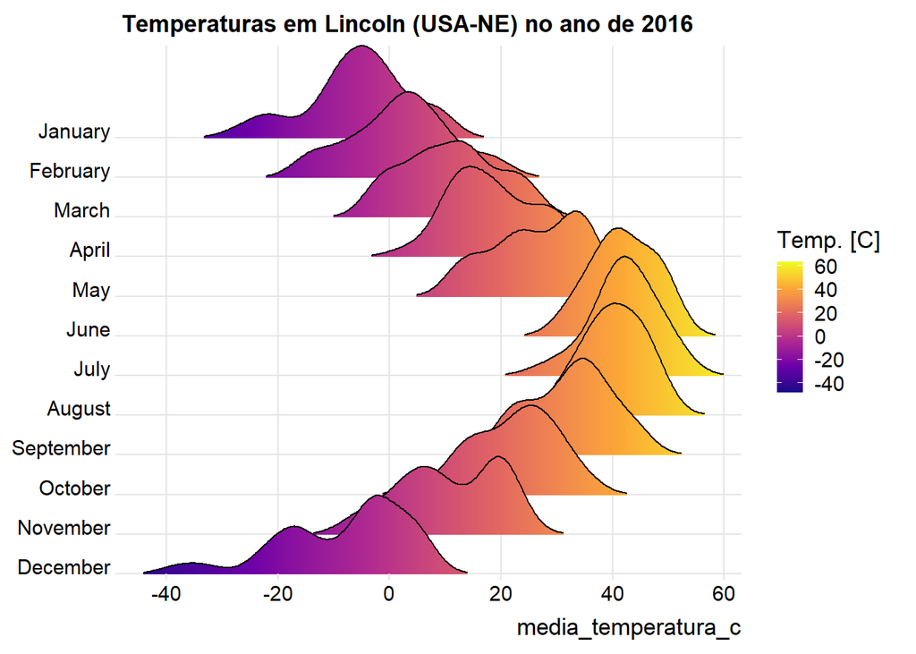

```r
ggridges::lincoln_weather %>%
  janitor::clean_names() %>%
  mutate(media_temperatura_c = (mean_temperature_f - 32)/1,8) %>%
  ggplot(aes(x = media_temperatura_c, y = month, fill = stat(x))) +
  ggridges::geom_density_ridges_gradient(scale = 3, rel_min_height = 0.01) +
  scale_x_continuous(expand = c(0, 0)) +
  scale_y_discrete(expand = c(0, 0)) +
  scale_fill_viridis_c(name = "Temp. [C]", option = "C") +
  coord_cartesian(clip = "off") +
  labs(title = 'Temperaturas em Lincoln (USA-NE) no ano de 2016') +
  ggridges::theme_ridges(font_size = 13, grid = TRUE) +
  theme(axis.title.y = element_blank())
## Picking joint bandwidth of 3.37
```

Agora comparando a distribuição dos dados, com as suas respectivas medidas de resumo:

```r
ggridges::lincoln_weather %>%
  janitor::clean_names() %>%
  mutate(media_temperatura_c = (mean_temperature_f - 32)/1,8) %>%
  select(month, media_temperatura_c) %>%
  group_by(month) %>%
  skimr::skim() %>%
  skimr::yank("numeric")
```

**Variable type: numeric**

| skim_variable | month | n_missing | complete_rate | mean | sd | p0 | p25 | p50 | p75 | p100 | hist |
| --- | --- | --- | --- | --- | --- | --- | --- | --- | --- | --- | --- |
| media_temperatura_c | December | 0 | 1 | -8.29 | 11.38 | -38 | -16.00 | -3.0 | -0.50 | 6 | ▂▂▆▇▇ |
| media_temperatura_c | November | 0 | 1 | 10.63 | 8.90 | -7 | 4.25 | 9.5 | 19.00 | 24 | ▂▅▅▂▇ |
| media_temperatura_c | October | 0 | 1 | 22.29 | 7.47 | 5 | 16.50 | 23.0 | 28.00 | 35 | ▂▇▆▇▅ |
| media_temperatura_c | September | 0 | 1 | 32.53 | 7.10 | 20 | 28.00 | 34.0 | 36.75 | 45 | ▇▃▇▇▃ |
| media_temperatura_c | August | 0 | 1 | 40.23 | 5.12 | 30 | 37.00 | 40.0 | 45.00 | 49 | ▂▅▇▆▃ |
| media_temperatura_c | July | 0 | 1 | 42.06 | 5.78 | 27 | 39.00 | 42.0 | 45.50 | 53 | ▂▁▇▆▃ |
| media_temperatura_c | June | 0 | 1 | 41.93 | 5.40 | 31 | 39.00 | 41.0 | 47.50 | 50 | ▂▃▇▅▇ |
| media_temperatura_c | May | 0 | 1 | 26.58 | 7.98 | 13 | 21.00 | 26.0 | 34.00 | 38 | ▅▅▅▅▇ |
| media_temperatura_c | April | 0 | 1 | 18.43 | 7.54 | 3 | 12.25 | 17.5 | 24.75 | 31 | ▂▇▅▅▅ |
| media_temperatura_c | March | 0 | 1 | 11.03 | 8.36 | -2 | 5.50 | 13.0 | 16.50 | 26 | ▆▇▇▃▆ |
| media_temperatura_c | February | 0 | 1 | 2.07 | 9.05 | -15 | -4.00 | 3.0 | 8.00 | 20 | ▅▅▇▅▂ |
| media_temperatura_c | January | 0 | 1 | -5.81 | 9.10 | -27 | -9.50 | -4.0 | -0.50 | 9 | ▃▂▆▇▃ |

Como mensagem final, vou citar Laplace:

> “The theory of probabilities is at bottom nothing but common sense reduced to calculus; it enables us to appreciate with exactness that which accurate minds feel with a sort of instinct for which ofttimes they are unable to account” (Laplace, 1812)

Algo como: “No fundo, a teoria das probabilidades é apenas o sesnso comum expresso em números; nos permite apreciar com exatidão o que as mentes acuradas sentem com uma espécie de instinto pelo qual muitas vezes são incapazes de explicar”. Pois bem, agora você é capaz :)

## 3. Medidas de Associação

Por fim vamos comententar de medidas que nos permitem reduzir a um único número a relação entre duas variáveis:

- Medidas de Dependência ou Associação (absoluta): covariância (cov)
- Medidas de Dependência ou Associação (relativa): correlação (usualmente, r ou ρ)

No caso da covariância temos a questão de ser uma métrica absoluta, tornando díficil interpretar a sua magnitude. Enquanto que a correlação pode ser entendido como uma versão normalizada da covariância, permitindo uma leitura muito mais direta, visto ter como propriedade a variação entre -1 e 1. No caso em que o valor é próximo a 1, temos o indício de uma tendência positiva entre as variáveis, indicando que ao desenhar um gráfico de dispersão (também conhecido como `scatter plot`) entre as duas variáveis, teremos os pontos próximos a uma linha reta crescente (coeficiente angular positivo). Enquanto que se o valor se aproximar de -1, temos indícios de uma associação negativa. Por fim uma correlação próxima de zero significa que as observações não apresentam associações lineares, interpretariamos aqui um comportamento mais próximo de uma nuvem de pontos aleatória ou ainda uma relação não-linear.

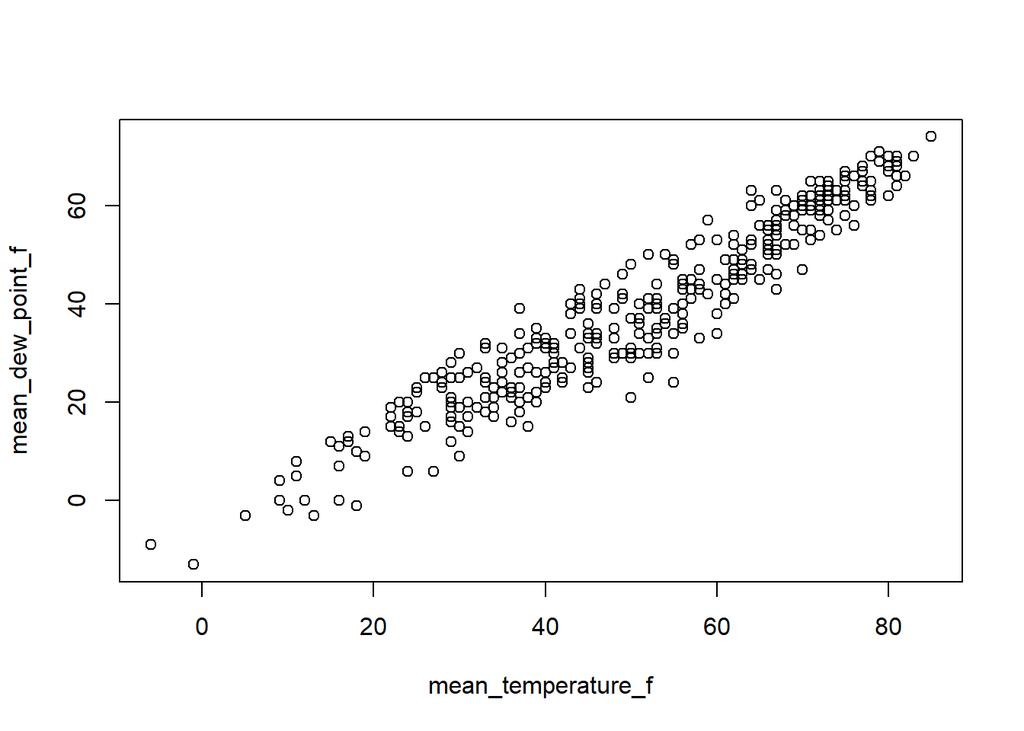

```r
ggridges::lincoln_weather %>%
  janitor::clean_names() %>%
  select(mean_temperature_f, mean_dew_point_f) %>%
  plot()
```

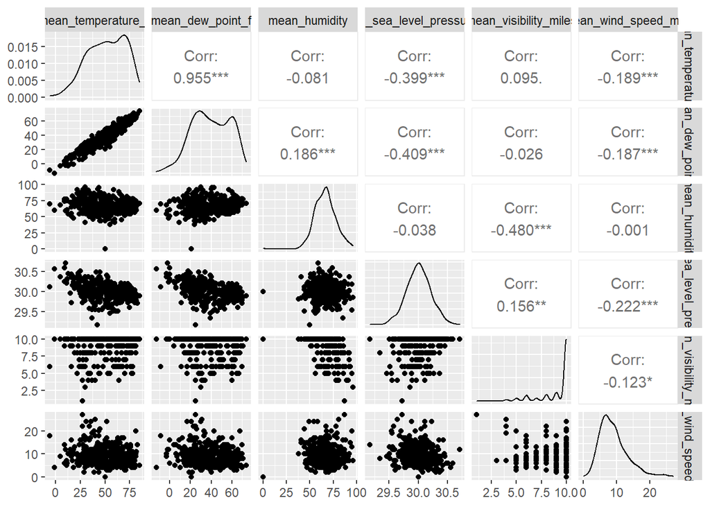

```r
ggridges::lincoln_weather %>%
  janitor::clean_names() %>%
  select(contains("mean_")) %>%
  select(where(is.numeric)) %>%
  GGally::ggpairs(progress = FALSE)
## Registered S3 method overwritten by 'GGally':
##   method from
##   +.gg   ggplot2
```

Um ponto importante, mas que não aprofundaremos aqui, é a relação entre o cálculo de medidas de dependência e os diferentes tipos de variáveis. Considerando coeficientes de correlação de: Pearson, Spearman, Kendall, entre outros.

Por fim sempre importante lembrar que: correlação não significa causalidade! Ou seja, não é porque existe uma correlação forte entre dois atributos, que um irá necessariamente causar a mudança de movimento no outro. Dois termos interessantes para pesquisar e entender melhor sobre este tipo de fenômeno, são: variável de confusão e correlação espúria. Para esta última indico este material incrível para ilustrar, de forma leve, a aplicação deste conceito: [Spurious Correlations](http://tylervigen.com/spurious-correlations).

# Considerações Finais sobre EDA

EDA é sobre interação! Quanto mais você investiga, mais informações terá para que os próximos passos da exploração sejam mais efetivos e **insightful** (esclarecedores). Aqui, ter uma abordagem curiosa e cientifica é extramemente recomendado, basicamente: pensar em hipóteses, investigá-las, criar novas conjecturas, e seguir interando. Esta é, talvez, uma das melhores maneira de lidar com EDA, tanto por ser baseado no pensamento científico, quanto por nos ajudar a lidar com o dolorido fato de que: não sabemos o que vamos encontrar, e que tá tudo bem! Pois faz parte do processo! O John Tukey, um importante estatístico do século passado, visto por muitos como um dos pais da EDA, tem uma frase famosa que diz:

> “EDA is an attitude, a state of flexibility, a willingness to look for those things that we believe are not there, as well as those we believe to be there” (Tukey, 1986).

Em português seria algo como: ““EDA é uma atitude, um estado de flexibilidade, uma vontade de procurar por coisas que acreditamos que não existem, assim como por coisas que acreditamos que estão lá”, poético né?

E para “procurar por coisas”, quanto mais ferramentas você possuir, melhor. Aprender a arte de manusear, transformar e visualizar dados, por exemplo. E são estes os temas que veremos na sequência.

Até lá ;)

# MÃO NA MASSA!

- No R você irá encontrar dezenas de pacotes com o objetivo de “facilitar” a sua visão, particularmente para a exploração descritiva de dados. Bibliotecas como: `visdat`, `naniar`, `DataExplorer`, entre tantas outras. Que tal explorar um pouco estes pacotes?
- Discutimos sobre distribuições empíricas utilizando o exemplo dado na [Seção 4.2.1 do livro Feature Engineering and Selection: A Practical Approach for Predictive Models](http://www.feat.engineering/visualizations-for-numeric-data-exploring-train-ridership-data.html). Neste mesmo capítulo são dados outros exemplos excelentes sobre como podemos tirar *insights* a partir da avaliação da distribuição dos dados.
- E em relação às distribuições de frequências, você já ouviu falar da distribuição Normal (Gaussiana)? Ou talvez da distribuição Poisson? Exponencial? Já refletiu sobre o porquê estudamos tantas distribuições? Para te ajudar a elaborar a resposta, avalie este [Aplicativo Shiny para explorar distribuições de probabilidade](https://antoinesoetewey.shinyapps.io/statistics-101/), e responda: considerando as características que foram citadas sobre a caracterização de distribuições, alguma das distribuições apresentadas teriam conclusões parecidas em termos de: concentração, dispersão, outliers e forma.